# Object 2

Jeongwon Yoo

2025-10-15

# Object 2

Investigate Environmental Factors Influencing Fire Incidences-Jeongwon Yoo

## 1. Data Integration

```r
# Read CSV
clean_df = '/Users/jeongwonyoo/Documents/GitHub/introds-project1/Fire incidences DC_VA_MD_cleaned.csv'
raw_df = '/Users/jeongwonyoo/Documents/GitHub/introds-project1/Wildfire_Dataset.csv'

library('readr')
clean_df = read_csv(clean_df)
raw_df = read_csv(raw_df)

# Make row_df columns names same as clean_df
names(raw_df) = toupper(names(raw_df))

# Add State name on raw data
options(tigris_use_cache = TRUE)

states = tigris::states(cb = TRUE, year = 2023) %>%
    st_transform(4326) %>%
    select(STUSPS, NAME, geometry)

sf_raw = st_as_sf(raw_df %>% filter(!is.na(LATITUDE), !is.na(LONGITUDE)),coords = c("LONGITUDE","LATITUDE"), crs = 4326, remove=FALSE)

raw_with_state_poly = st_join(sf_raw, states, join = st_within) %>%
    st_drop_geometry() %>%
    rename(STATE = STUSPS)

# sort target data(state(VA,DC,MD),time(2018))
target_states = c("DC","MD","VA")
target_year = 2018
cols_keep = c("STATE","FIRE_YEAR","Month","LATITUDE","LONGITUDE",
                   "DATETIME","PR","RMAX","RMIN","SPH","SRAD","TMMN",
                  "TMMX","VS","BI","FM100","FM1000","ERC","ETR","PET","VPD")

# Make sub dataset of clean_df
clean_sub = clean_df %>%
    filter(STATE %in% target_states,
           FIRE_YEAR == target_year) %>%
    select(any_of(cols_keep))

# Make sub dataset of raw_df
raw_sub = raw_with_state_poly %>%
    filter(STATE %in% target_states,
           lubridate::year(lubridate::as_datetime(DATETIME)) == target_year) %>%
    drop_na(LATITUDE, LONGITUDE) %>%
    select(any_of(cols_keep))

# organized data check
str('raw_sub')
```

Call new dataset for the analysis

Variable definitions used in the analysis

| Variable | Description | Units |
| --- | --- | --- |
| PR | Precipitation | mm/day |
| RMAX / RMIN | Relative humidity (Maximum / Minimum) | % |
| SPH | Specific humidity | kg/kg |
| SRAD | Solar radiation | W/m² |
| TMMN / TMMX | Temperatures (Minimum / Maximum) | °C |
| VS | Wind speed | m/s |
| VPD | Vapor pressure deficit | kPa |
| FM100 / FM1000 | Fuel moisture indices | % |
| ERC | Energy Release Component | index |
| BI | Burning Index | index |
| ETR / PET | Evapotranspiration (ETR) / Potential (PET) | mm/day |

## 2. Correlation Analysis

Correlation Analysis

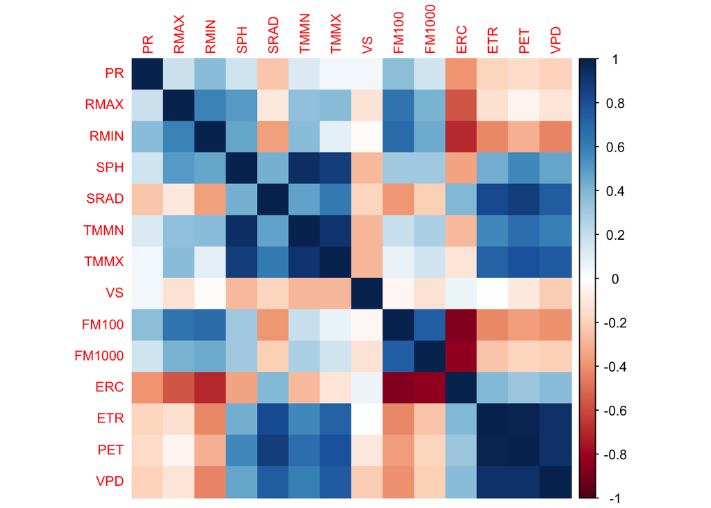

### 2.1. Raster Maps

Figure: Maximum Temperature Distribution (°C)

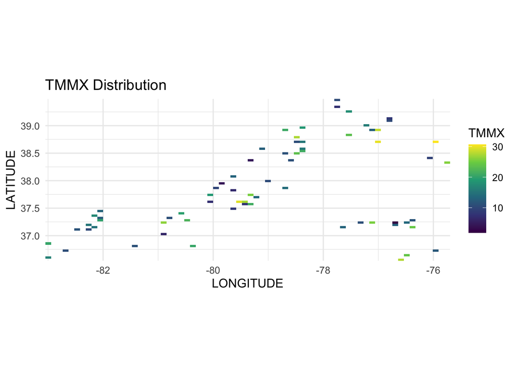

TMMX(C) binned raster map

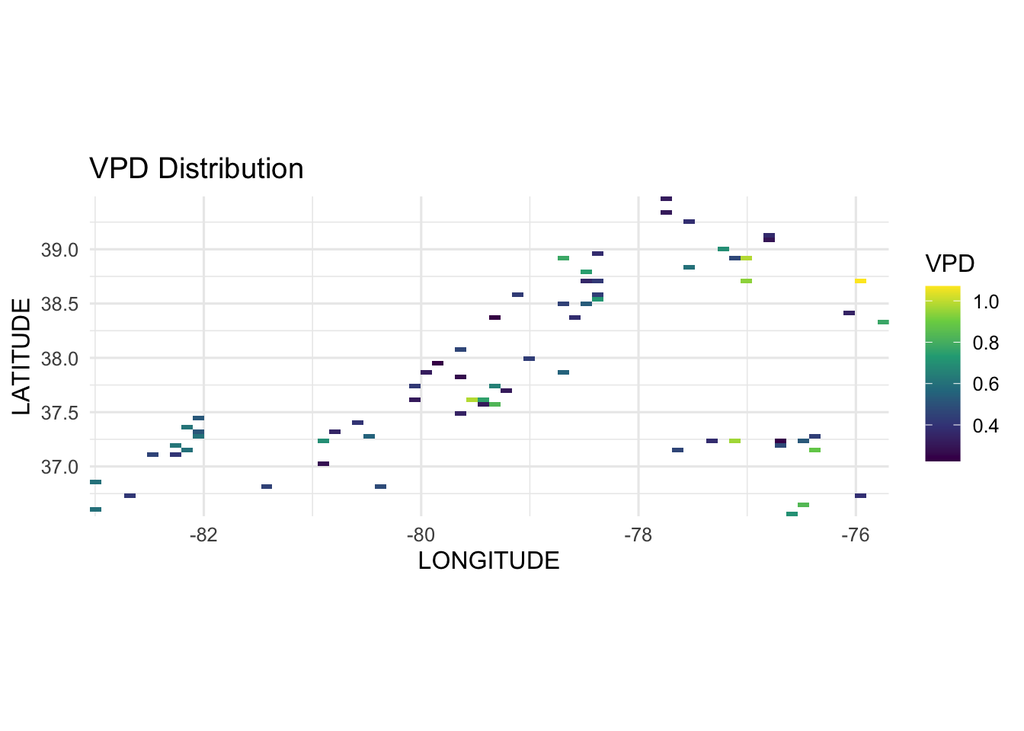

VPD binned raster map

- Higher VPD (drier air) pockets appear in many of the same eastern and central areas that are warmer
- The co-location of high TMMX and high VPD indicates jointly hot-dry conditions that elevate fire potential

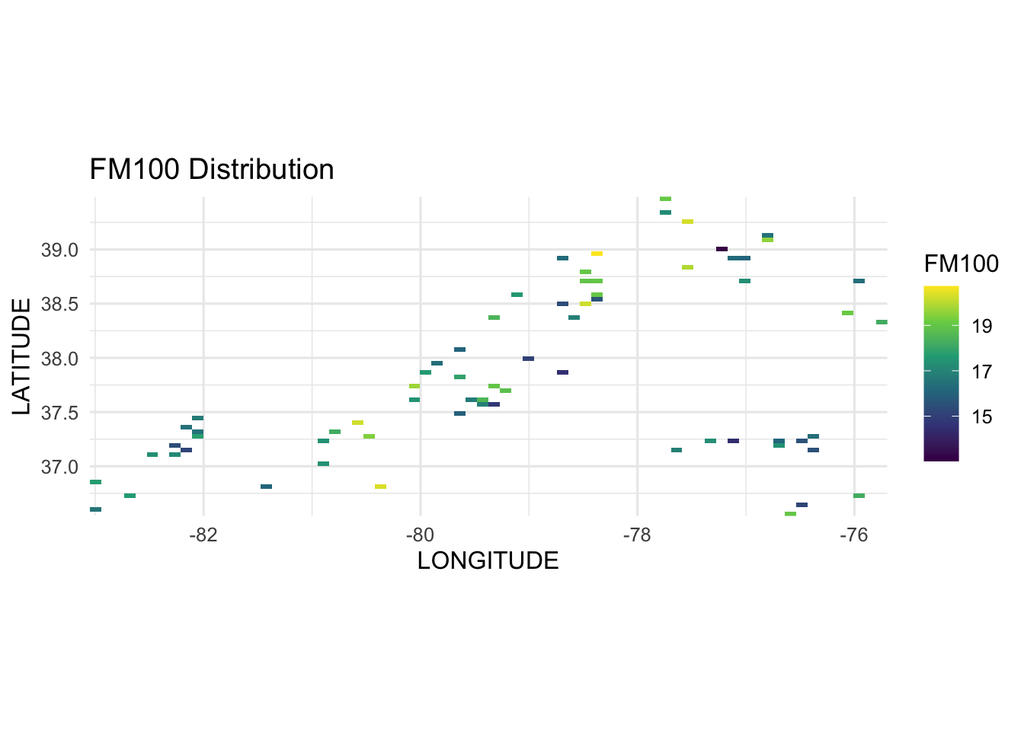

FM100 binned raster map

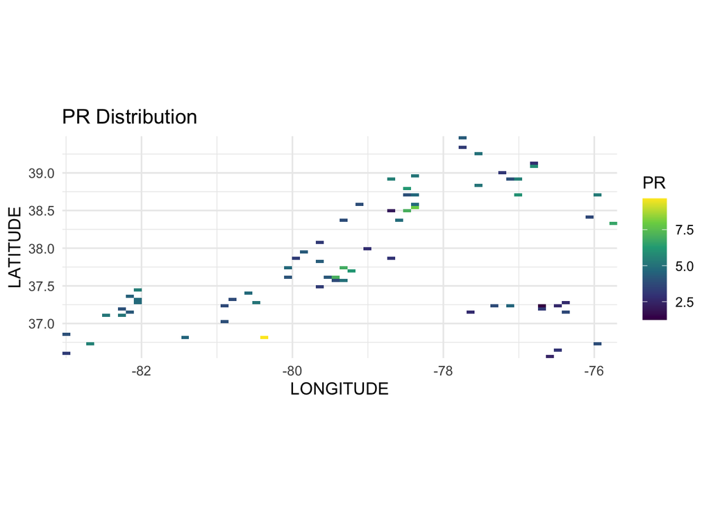

PR(precipitation) binned raster map - Precipitation is patchy and relatively low over much of the domain - Where PR is higher, ERC tends to be lower in the ERC map (Figure 7), consistent with wetting effects

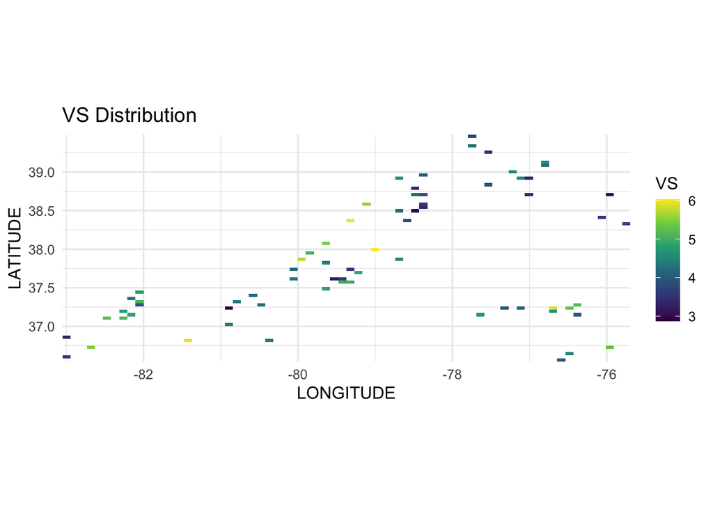

VS(Wind Speed) binned raster map - Wind has localized maxima rather than a single gradient - These wind pockets may not align perfectly with ERC spatial highs, which is consistent with wind acting more as a spread/short-term enhancer than a persistent background driver.

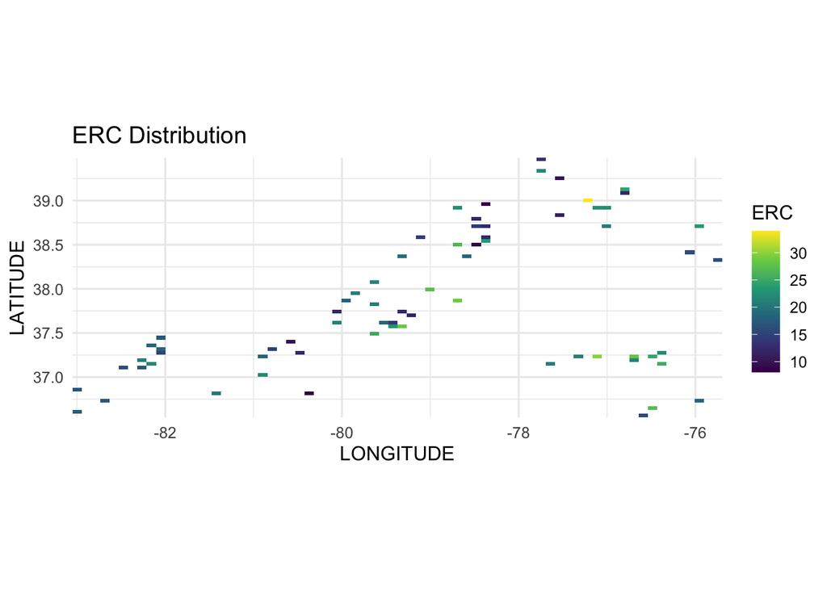

### 2.2. Scatter Plots

Scatter Plots

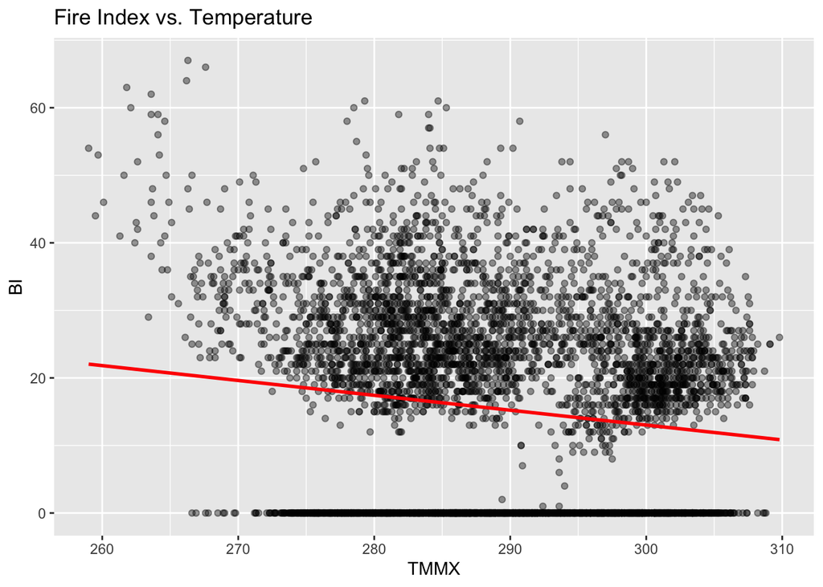

BI vs. TMMX

- The fitted line shows a weak relationship and the distribution is dominated by many zero or near-zero BI values. This zero inflation and visible heteroscedasticity limit the usefulness of simple bivariate OLS. A multivariable model that controls for dryness (VPD), fuel moisture (FM100), wind (VS), and precipitation (PR) is more appropriate. If the goal is to model BI directly, consider restricting to BI > 0 or using a model that handles zero inflation or nonlinearity.

### 2.3 Regression Diagnostics Plots

Regression Diagnostics Plots

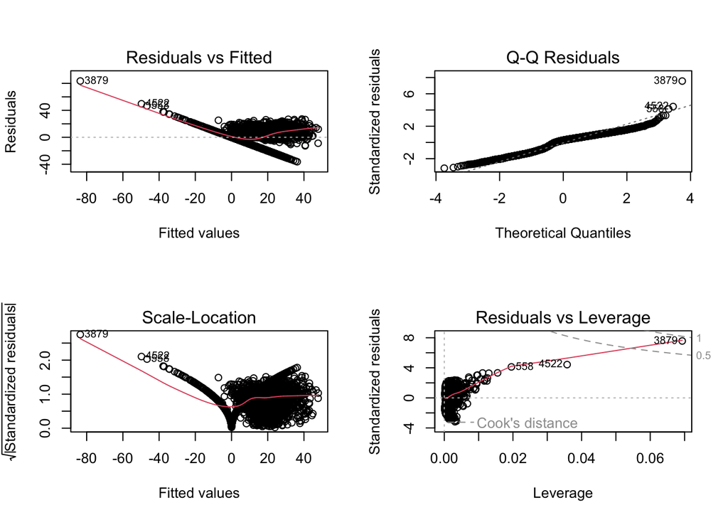

OLS diagnostic for BI model - Residuals vs. fitted values display a fan shape and curvature, which indicates heteroscedasticity and potential nonlinearity - The Q–Q plot shows tail deviations, suggesting heavy-tailed residuals and outliers. The scale-location plot confirms nonconstant variance - The residuals vs leverage plot highlights a few influential observations. These patterns show that standard OLS assumptions are not well met and motivate spatial regression or robust alternatives.

### 2.4 Spatial Regression

The code chunk is taking long-running: disabled during knit (works in Console). Keep full code here for reproducibility and results pasted below.

```r
o2 = object2 %>%
  group_by(LONGITUDE, LATITUDE) %>%
  summarise(across(c(PR, RMAX, RMIN, SPH, SRAD, TMMN, TMMX, VS,
                     FM100, FM1000, ERC, ETR, PET, VPD),
                   ~mean(.x, na.rm = TRUE)), .groups = "drop") %>%
  mutate(id = row_number())

vars = c("ERC","TMMX","VPD","FM100","PR","VS","RMAX","SRAD")

keep_logical = complete.cases(o2[, vars])

dat = o2[keep_logical, c(vars, "id"), drop = FALSE]
stopifnot(nrow(dat) > 1)

coords = as.matrix(o2[, c("LONGITUDE","LATITUDE")])
coords_k = coords[dat$id, , drop = FALSE]
stopifnot(nrow(coords_k) == nrow(dat))

k = 8
repeat {
  nb = knn2nb(knearneigh(coords_k, k = k, longlat = TRUE))
  if (n.comp.nb(nb)$nc == 1 || k >= 20) break
  k = k + 2
}

lw_k = nb2listw(nb, style = "W", zero.policy = FALSE)

xvars = c("TMMX","VPD","FM100","PR","VS","RMAX","SRAD")
dat_std = dat
dat_std[xvars] = scale(dat_std[xvars])

ols = lm(ERC ~ TMMX + VPD + FM100 + PR + VS + RMAX + SRAD, data = dat_std)
sem = errorsarlm(ERC ~ TMMX + VPD + FM100 + PR + VS + RMAX + SRAD,
                  data = dat_std, listw = lw_k, na.action = na.exclude)

summary(ols)
summary(sem)
moran.test(residuals(ols), lw_k)
moran.test(residuals(sem), lw_k)
```

#### Result

- summary(ols)

Call: lm(formula = ERC ~ TMMX + VPD + FM100 + PR + VS + RMAX + SRAD, data = dat_std)

Residuals: Min 1Q Median 3Q Max -4.7305 -1.2031 0.2945 1.4940 3.0632

Coefficients: Estimate Std. Error t value Pr(>|t|)  
(Intercept) 19.0706 0.2347 81.252 < 2e-16 TMMX -1.5034 1.3189 -1.140 0.258491  
VPD 1.0727 1.2690 0.845 0.401050  
FM100 -4.8261 1.1851 -4.072 0.000129 PR -1.0014 0.3540 -2.829 0.006203 ** VS -0.2254 0.3353 -0.672 0.503884  
RMAX 0.1135 0.8120 0.140 0.889270  
SRAD 0.2321 0.7866 0.295 0.768867  
— Signif. codes: 0 ’’ 0.001 ’’ 0.01 ’’ 0.05 ‘.’ 0.1 ‘ ’ 1

Residual standard error: 2.005 on 65 degrees of freedom Multiple R-squared: 0.9028, Adjusted R-squared: 0.8924 F-statistic: 86.28 on 7 and 65 DF, p-value: < 2.2e-16

- summary(sem)

Call:errorsarlm(formula = ERC ~ TMMX + VPD + FM100 + PR + VS + RMAX + SRAD, data = dat_std, listw = lw_k, na.action = na.exclude)

Residuals: Min 1Q Median 3Q Max -4.00770 -1.09347 0.12968 1.09124 2.98286

Type: error Coefficients: (asymptotic standard errors) Estimate Std. Error z value Pr(>|z|) (Intercept) 19.12921 0.60304 31.7211 < 2.2e-16 TMMX -2.10797 0.88425 -2.3839 0.01713 VPD 2.08839 0.91643 2.2788 0.02268 FM100 -4.32810 0.81694 -5.2979 1.171e-07 PR -0.56119 0.24728 -2.2694 0.02324 VS -0.23018 0.26144 -0.8804 0.37863 RMAX -0.50397 0.56725 -0.8884 0.37430 SRAD -0.11324 0.57086 -0.1984 0.84277

Lambda: 0.72518, LR test value: 36.149, p-value: 1.8279e-09 Asymptotic standard error: 0.082947 z-value: 8.7427, p-value: < 2.22e-16 Wald statistic: 76.435, p-value: < 2.22e-16

Log likelihood: -132.0661 for error model ML residual variance (sigma squared): 1.9885, (sigma: 1.4101) Number of observations: 73 Number of parameters estimated: 10 AIC: 284.13, (AIC for lm: 318.28)

- moran.test(residuals(ols), lw_k)

  Moran I test under randomisation

data: residuals(ols)  
weights: lw_k

Moran I statistic standard deviate = 9.0678, p-value < 2.2e-16 alternative hypothesis: greater sample estimates: Moran I statistic Expectation Variance 0.450965435 -0.013888889 0.002628031

- moran.test(residuals(sem), lw_k)

  Moran I test under randomisation

data: residuals(sem)  
weights: lw_k

Moran I statistic standard deviate = -0.12209, p-value = 0.5486 alternative hypothesis: greater sample estimates: Moran I statistic Expectation Variance -0.020133928 -0.013888889 0.002616504

#### Result Description

Model comparison

- SEM preferred: AIC(SEM) = 284.13 vs AIC(OLS) = 318.28 (ΔAIC ≈ 34 → choose SEM)
- Spatial error (λ): 0.725 (SE 0.083), z = 8.74, p < 0.001 → strong spatial error dependence present.

Residual spatial autocorrelation

- OLS residuals: Moran’s I = 0.451, z = 9.07, p < 0.001 → pronounced spatial clustering (OLS inadequate).
- SEM residuals: Moran’s I = −0.020, z = −0.12, p = 0.55 → not significant → spatial structure adequately modeled

SEM coefficients (standardized predictors) - VPD (+): β = +2.088, p = 0.023 → drier air increases ERC - FM100 (−): β = −4.328, p < 0.001 → higher fuel moisture lowers ERC (strongest effect) - PR (−): β = −0.561, p = 0.023 → more precipitation lowers ERC - TMMX (±): β = −2.108, p = 0.017 → negative once VPD is included (suppression/collinearity with VPD) - VS, RMAX, SRAD: not significant in this multivariable, spatially corrected model.

Interpretation highlights

- Key drivers: higher dryness (VPD) and lower fuel moisture (FM100) raise fire potential; precipitation reduces it
- TMMX vs VPD: because they’re correlated, VPD captures the hot–dry signal; with VPD in the model, TMMX can flip negative (suppression). For a simpler story, use VPD as the primary dryness proxy

The SEM substantially improves fit and removes residual spatial clustering, confirming that dryness↑, fuel moisture↓, and precipitation↓ are the dominant environmental controls on ERC.

- last edit by simba
- added other plots and finializing it(Jeongwon)